# Linear Regression

Sarahy Martinez

2024-11-12

```r
library(tidyverse)
library(p8105.datasets)
set.seed(1)
```

```r
data("nyc_airbnb")

#standard data cleaning steps
nyc_airbnb =
  nyc_airbnb |>
  mutate(stars = review_scores_location / 2) |>
  rename(
    borough = neighbourhood_group,
    neighborhood = neighbourhood) |> # changed spelling of neighbourhood
  filter(borough != "Staten Island") |>
  select(price, stars, borough, neighborhood, room_type)
```

## Fit a model

An good place to start is to consider price as an outcome that may depend on rating and borough. We fit that initial model in the following code.

want to fit the stars (numeric) and borough ( categorical)

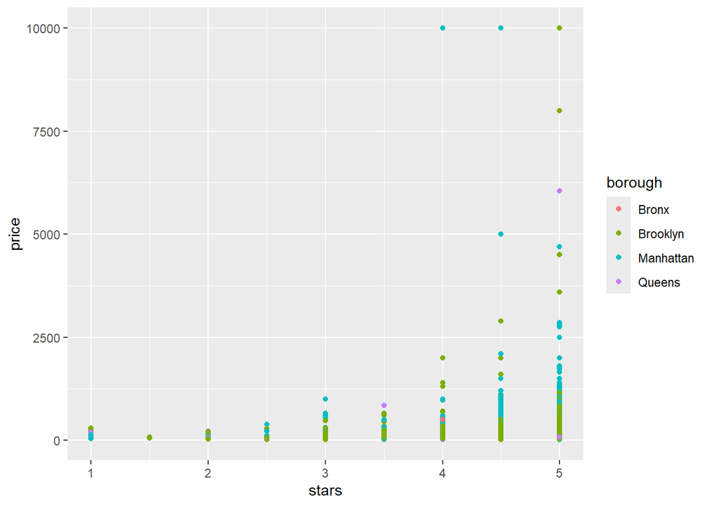

```r
nyc_airbnb %>%
  ggplot(aes(x= stars, y =price, color = borough))+
  geom_point()
```

```r
# we see alot of overlap and so what we want to do is fit some line that runs through stars and is different for each borough and will try to get parallel lines.
```

Lets fit the model we care about -> a linear model that relates price to stars and boro. Save it as fit; only fitting one model and later overriding.

The lm function begins with the formula specification – outcome on the left of the ~ and predictors separated by + on the right. As we’ll see shortly, interactions between variables can be specified using *. You can also specify an intercept-only model (outcome ~ 1), a model with no intercept (outcome ~ 0 + …), and a model using all available predictors (outcome ~ .).

R will treat categorical (factor) covariates appropriately and predictably: indicator variables are created for each non-reference category and included in your model, and the factor level is treated as the reference. As with ggplot, being careful with factors is therefore critical!

```r
nyc_airbnb =
  nyc_airbnb |>
  mutate(
    borough = fct_infreq(borough),
    room_type = fct_infreq(room_type))

fit = lm(price ~ stars + borough, data = nyc_airbnb)
```

It’s important to note that changing reference categories won’t change “fit” or statistical sigificance, but can affect ease of interpretation.